# Kernel density estimation in R spatial

Here’s one way to do kernel density estimation in R spatial

## Packages

This requires a surprising number of moving parts (at least the way I did it):

```r
library(sf)
library(tmap)
library(spatstat)
library(maptools)
library(raster)
library(dplyr)
```

## Data

The data are some point data (Airbnb listings from [here](http://insideairbnb.com/new-zealand/)) and some polygon data (NZ census Statistical Area 2 data).

### Load the data

```r
polys <- st_read("sa2.gpkg")
pts <- st_read("abb.gpkg")
```

And have a look

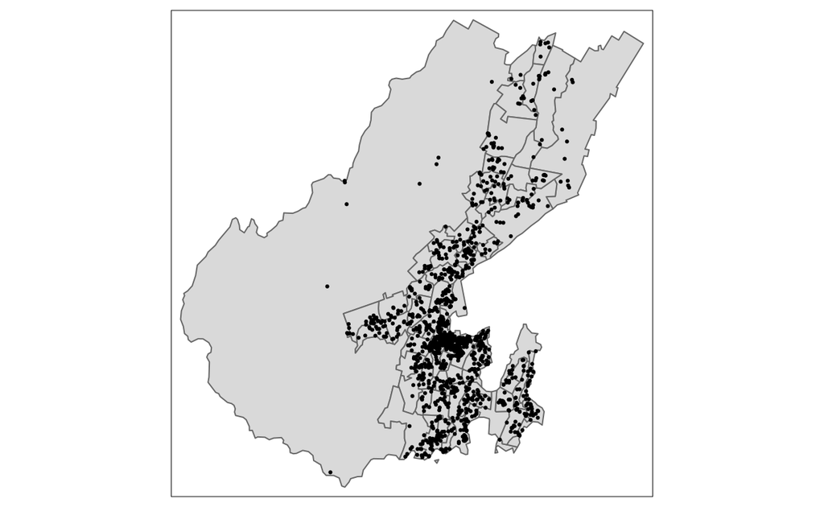

```r
tm_shape(polys) +
  tm_polygons() +
  tm_shape(pts) +
  tm_dots()
```

## `spatstat` for density estimation

The best way I know to do density estimation in the *R* ecosystem is using the [`spatstat`](https://spatstat.org/) library’s specialisation of base *R*’s `density` function. That means converting the point data to a `spatstat` planar point pattern (`ppp`) object, which involves a couple of steps.

```r
pts.ppp <- pts$geom %>%
  as("Spatial") %>% # we need to convert to sp as a bridge to spatstat
  as.ppp()          # and this is what we need maptools for...
```

A point pattern also needs a ‘window’, which we’ll make from the polygons.

```r
pts.ppp$window <- polys %>%
  st_union() %>%       # combine all the polygons into a single shape
  as("Spatial") %>%    # convert to sp
  as.owin()            # convert to spatstat owin - again maptools...
```

### Now the kernel density

We need some bounding box info to manage the density estimation resolution

```r
bb <- st_bbox(polys)
cellsize <- 100
height <- (bb$ymax - bb$ymin) / cellsize
width <- (bb$xmax - bb$xmin) / cellsize
```

Now we specify the size of the raster we want with `dimyx` (note the order, y then x) using `height` and `width`.

We can convert this directly to a raster, but have to supply a CRS which we pull from the original points input dataset. At the time of writing (August 2021) you’ll get a complaint about the New Zealand Geodetic Datum 2000 because recent changes in how projections and datums are handled are still working themselves out.

```r
kde <- density(pts.ppp, sigma = 500, dimyx = c(height, width)) %>%
  raster()
crs(kde) = st_crs(pts)$wkt  # a ppp has no CRS information so add it
```

### Let’s see what we got

We can map this using `tmap`.

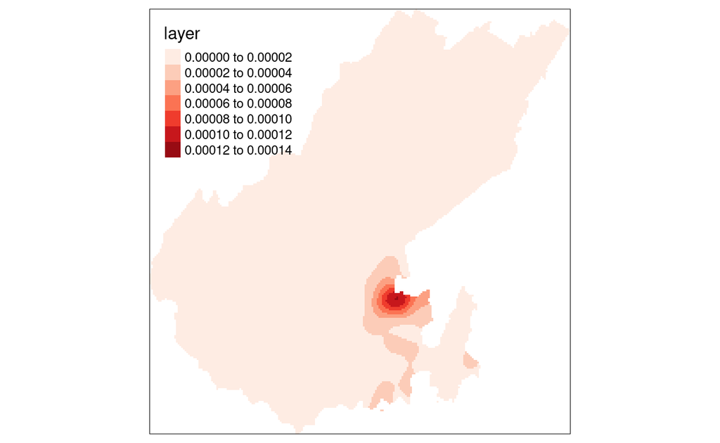

```r
tm_shape(kde) +
  tm_raster(palette =  "Reds")
```

### A fallback sanity check

To give us an alternative view of the data, let’s just count points in polygons

```r
polys$n <- polys %>%
  st_contains(pts) %>%
  lengths()
```

And map the result

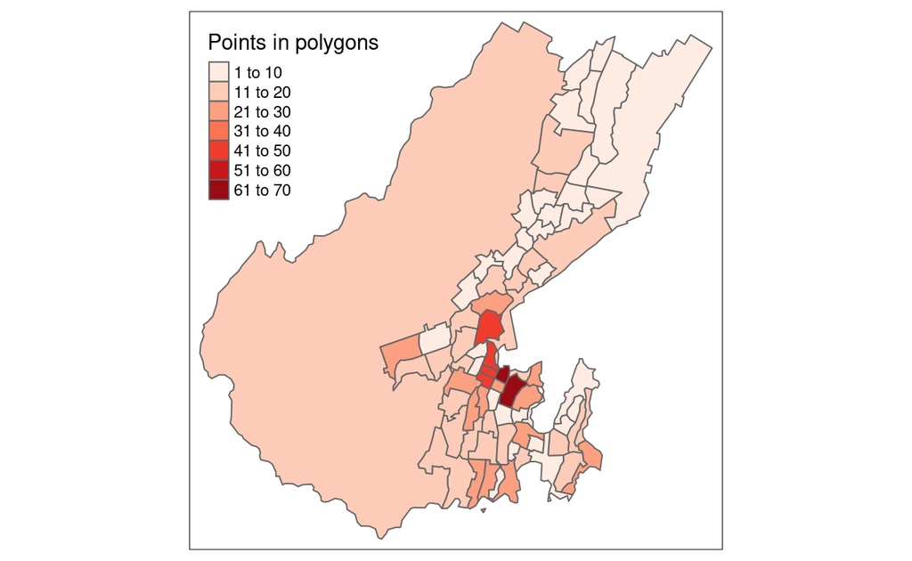

```r
tm_shape(polys) +
  tm_polygons(col = "n", palette = "Reds", title = "Points in polygons")
```

### Aggregate the density surface pixels to polygons

This isn’t at all necessary, but is also useful to know. This is also a relatively slow operation. Note that we add together the density estimates in the pixels contained by each polygon.

```r
summed_densities <- raster::extract(kde, polys, fun = sum)
```

Append this to the polygons and rescale so the result is an estimate of the original count. We multiply by `cellsize^2` because each cell contains an estimate of the per sq metre (in this case, but per sq distance unit in general) density, so multiplying by the area of the cells gives an estimated count.

```r
polys$estimated_count = summed_densities[, 1] * cellsize ^ 2
```

And now we can make another map

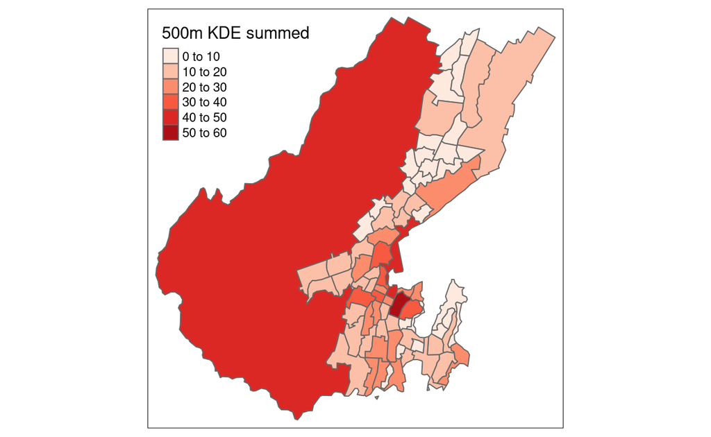

```r
tm_shape(polys) +
  tm_polygons(col = "estimated_count", palette = "Reds",
              title = "500m KDE summed")
```

Spot the deliberate mistake?!

Something doesn’t seem quite right! What’s with the large numbers in the large rural area to the west of the city? Thing is, you shouldn’t really map count data like this, but should instead convert to densities. If we include that option in the `tm_polygons` function, then order is restored.

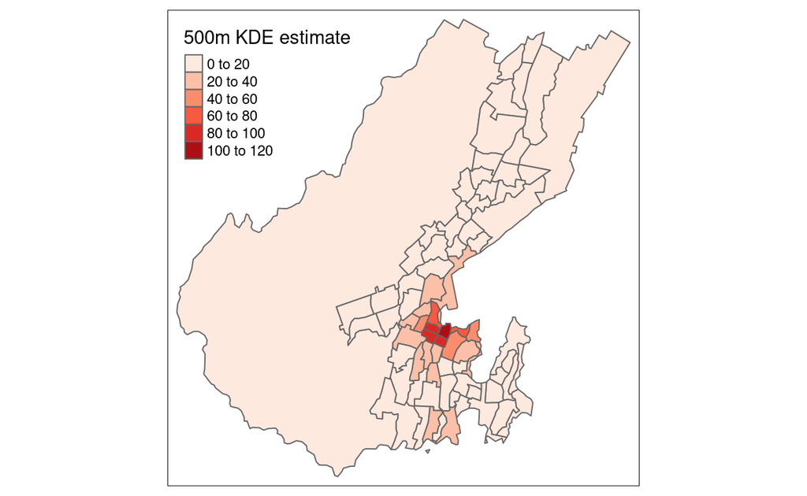

```r
tm_shape(polys) +
  tm_polygons(col = "estimated_count", palette = "Reds", convert2density = TRUE,
              title = "500m KDE estimate")
```

Really, this should be done with the earlier map of points in polygons too, so let’s show all three side by side. `tmap_arrange` is nice for this, although it has trouble making legend title font sizes match, unless you do some creative renaming. I’ve also multiplied the KDE result by 1,000,000 to convert the density to listings per sq. km, and we can see that the three maps are comparable.

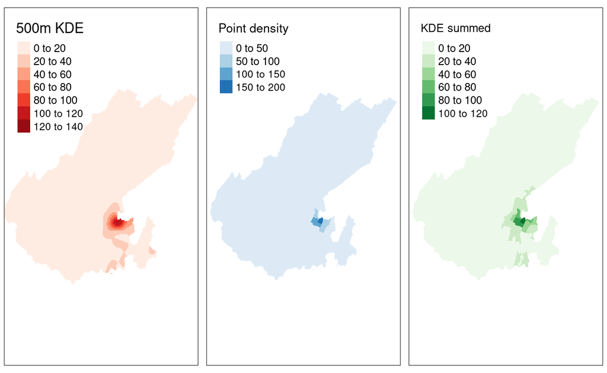

```r
m1 <- tm_shape(kde * 1000000) +
  tm_raster(palette = "Reds", title = "500m KDE")
m2 <- tm_shape(polys) +
  tm_fill(col = "n", palette = "Blues", convert2density = TRUE,
              title = "Point density")
m3 <- tm_shape(polys) +
  tm_fill(col = "estimated_count", palette = "Greens", convert2density = TRUE,
              title = "KDE summed")
tmap_arrange(m1, m2, m3, nrow = 1)
```